# Quarto Workshop

📝 Plain text → 🌍 the world

Ravi Kalia

🌍 Prefer Spanish or another language? The [Google Translate extension](https://chromewebstore.google.com/detail/google-translate/aapbdbdomjkkjkaonfhkkikfgjllcleb) translates these slides; code stays as written.

## 🎯 Objective · 🏁 Outcome

🎯 Objective

Create **reproducible content** you can **share with the world**, using Quarto.

🏁 Outcome

Plain-text Markdown becomes

📄 docx 📕 pdf 📊 pptx 🎞️ revealjs 📖 epub ⭐ 🌐 website ✍️ blog 📈 dashboard

🤖 with the code written by your coding assistant

🌍 ¿Prefieres leer en español? La extensión Google Translate traduce estas diapositivas; el código no cambia. · [Google Translate](https://chromewebstore.google.com/detail/google-translate/aapbdbdomjkkjkaonfhkkikfgjllcleb)

## 🗓️ Agenda

| ⏱️ | Block | Min |
| --- | --- | --- |
| 0:00 | 👋 Welcome · 🎯 objective · 🏁 outcome | 5 |
| 0:05 | 🧭 What is Quarto? | 5 |
| 0:10 | 🛠️ Setup check · 🧰 boxes · 🗣️ prompting | 5 |
| 0:15 | 🇬🇧 Part 1 · London: Markdown → HTML, rules, environment | 20 |
| 0:35 | 🧪 Part 1 · `.md` → `.qmd`: YAML, code, docx + PDF | 10 |
| 0:45 | 🗂️ Part 1 · Four audiences, 🤖 sub-agents in parallel | 10 |
| 0:55 | 🌍 Part 1 · Publish to GitHub Pages | 10 |
| 1:05 | ☕ Break · 🛟 catch up | 10 |
| 1:15 | 💧 Part 2 · Colombia water quality and infant mortality | 125 |
| 3:20 | 🏁 Done |  |

🏠 before the workshop: install, setup check, 🧪 test run, 📖 [Markdown in Y minutes](https://learnxinyminutes.com/markdown/) · ⭐ = optional, self-paced

# 🧭 What is Quarto?

⏱️ 0:05

## Quarto = Markdown → anything

📚 [All Quarto output formats](https://quarto.org/docs/output-formats/all-formats.html) · Quarto logo: Posit, PBC

# 🛠️ Setup

⏱️ 0:10

## 🪟 Windows? Work inside Ubuntu

🐧

**Install inside Ubuntu**

Quarto, gh, uv and the assistant, in the WSL terminal

🏠

**Keep folders in `~`**

not under `/mnt/c`, which is slower

📂

**`explorer.exe .`**

opens this folder in Windows

➕

**Second tab: Ctrl+Shift+D**

`cd` to your folder, for `quarto preview`

## 🧩 No coding assistant yet?

🏠 before the workshop

**✳️ Claude Code**

`claude` · setup

```bash
curl -fsSL https://claude.ai/install.sh | bash
```

**🌀 Codex**

`codex` · [CLI guide](https://learn.chatgpt.com/docs/codex/cli)

```bash
curl -fsSL https://chatgpt.com/codex/install.sh | sh
```

**♊ Antigravity**

`agy` · Gemini · [docs](https://antigravity.google/docs/getting-started?tab=cli)

```bash
curl -fsSL https://antigravity.google/cli/install.sh | bash
```

Pick one · install, open a new terminal tab, then start it with its command (`claude`, `codex` or `agy`)

Install commands checked 2026-10-30. Windows: run them in Ubuntu (WSL).

## 🛠️ Setup check

🏠 before the workshop 🪟 on Windows, in the Ubuntu (WSL) terminal

```bash
quarto check
uv --version
gh auth status
claude --version
git config --global user.name "Your Name"
git config --global user.email "you@example.com"
cd ~ && git clone https://github.com/project-delphi/quarto-workshop.git
```

No `uv`? [Install uv](https://docs.astral.sh/uv/getting-started/installation/) · No `gh`? [Install the GitHub CLI](https://cli.github.com/), then `gh auth login` · 🤖 Codex: `codex --version` · Antigravity: `agy --version`

### Exercise · ⏱️ 4 min

`quarto check` and `uv --version` run, `gh auth status` says “Logged in”, and `~/quarto-workshop/checkpoints/` exists.

## 🧪 Test run: assistant → Quarto → PDF

🏠 before the workshop

```bash
mkdir -p ~/quarto-test && cd ~/quarto-test
claude    # or: codex, agy
```

🤷 no need to understand `hello.qmd` yet: Part 1 explains every piece

### Exercise · ⏱️ 5 min

`hello.html` and `hello.pdf` say 42, and you told the organiser.

## 📖 Markdown in Y minutes

🏠 before the workshop

👉 [learnxinyminutes.com/markdown](https://learnxinyminutes.com/markdown/) · 🇪🇸 [en español](https://learnxinyminutes.com/es/markdown/)

#

`#` headings

✳️

`*emphasis*` · `**bold**`

📋

`-` and `1.` lists

🔗

`[link](url)`

`![image](file)`

🧮

`| tables |` · `` ``` `` code fences

### Exercise · ⏱️ 5 min

you can name the Markdown for a heading, a link and a table.

## 🧰 Three boxes, three roles

👀 An example: you will paste prompts like this from Part 1 on.

writes `london.md` · may run `quarto render london.md`

approve its commands · open `london.html` in your browser

## 🗣️ How to prompt your coding assistant

🎯

**Be specific**

file names, columns, chart types

☝️

**One step at a time**

one task per prompt

✅

**Ask it to run & check**

“…render it and tell me about errors”

👀

**Check what changed**

you are responsible for the result

🌍 ¿Español? Your first prompt can be: `Responde siempre en español; deja el código y los nombres de archivo en inglés.`

# 🇬🇧 Part 1 · London in Markdown

⏱️ 0:15

## 🗺️ Part 1 in four blocks

📝

**0:15** Markdown → HTML · rules · environment

🧪

**0:35** `.md` → `.qmd`: YAML · code · docx + PDF

🗂️

**0:45** 🤖 four audiences in parallel

🌍

**0:55** publish to GitHub Pages

🏁 a live dashboard URL on your phone 📱

## 🏛️ You work for London’s tourism office

✍️ write **one** guide → ♻️ reuse it for every audience

```
📁 ~  (your home folder)
├── 📁 quarto-workshop/  ← clone
└── 📁 london-guide/     ← you
```

```bash
cd ~
mkdir -p london-guide && cd london-guide
claude
```

or `codex` / `agy` instead of `claude`

😰 Stuck for 2 min? Paste the exercise’s **Catch me up** prompt: 💾 backup → 📋 checkpoint → ▶️ render → ➡️ rejoin at the next ⏱️ block

## 1️⃣ Heading · paragraph · emphasis

```markdown
# Visit London

Welcome to **London**: free museums, royal history and *riverside walks*.
```

# Visit London

Welcome to **London**: free museums, royal history and *riverside walks*.

### Exercise · ⏱️ 1 min

😰 Stuck?

```
Catch me up: follow ../quarto-workshop/checkpoints/01-london-markdown/README.md
```

`london.md` has a heading and a welcome paragraph.

## ▶️ Render it

`quarto render london.md` → `london.html`

in a second terminal tab (Windows Terminal: Ctrl+Shift+D):

```bash
cd ~/london-guide && quarto preview london.md
```

live view, reloads on every change · Ctrl+C stops it

🚫 YAML · 🚫 code · ✅ a web page

### Exercise · ⏱️ 3 min

😰 Stuck?

```
Catch me up: follow ../quarto-workshop/checkpoints/01-london-markdown/README.md
```

`london.html` opens and updates whenever `london.md` changes.

## 📜 AGENTS.md: rules the assistant reads

🎯

**Scope**

what the project is, and is not

📏

**Rules**

what must always hold

⌨️

**Commands**

how to build and check it

🔁

**Every session**

Claude Code, Codex and Antigravity read it first

✍️ say it once → every session follows it

## 📜 Rules for the guide

writes `AGENTS.md`: a scope and a list of rules

approve · read it: does it say what you meant?

### Exercise · ⏱️ 2 min

😰 Stuck?

```
Catch me up: follow ../quarto-workshop/checkpoints/01-london-markdown/README.md
```

`AGENTS.md` states the guide’s scope and its three rules.

## 2️⃣ Lists

```markdown
## Five sights to start with

1. British Museum
2. Natural History Museum
3. Tate Modern
4. National Gallery
5. Tower of London

## Getting around

- 🚇 Tube
- 🚌 Bus
- 🚲 Santander Cycles
```

## Five sights to start with

1. British Museum
2. Natural History Museum
3. Tate Modern
4. National Gallery
5. Tower of London

## Getting around

- 🚇 Tube
- 🚌 Bus
- 🚲 Santander Cycles

### Exercise · ⏱️ 1 min

😰 Stuck?

```
Catch me up: follow ../quarto-workshop/checkpoints/01-london-markdown/README.md
```

each list has its own heading.

## 3️⃣ Link · image · quote

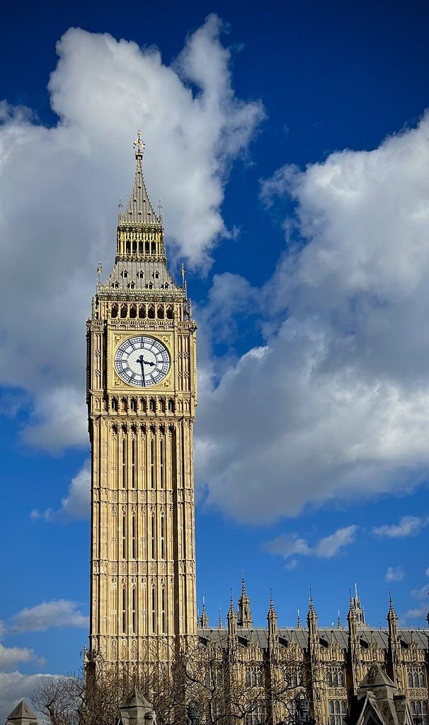

Big Ben in the sun. Photo: John Dillenbeck, CC0, via Wikimedia Commons

```markdown
Plan your route with the [TfL Journey Planner](https://tfl.gov.uk/plan-a-journey/).

![Big Ben in the sun. Photo: John Dillenbeck, CC0, via Wikimedia Commons](images/big-ben.jpg){width=30% fig-alt="Big Ben's clock tower …"}

> **Tip from a local:** many big museums are free. Book a free timed ticket to skip the queue.
```

Plan your route with the [TfL Journey Planner](https://tfl.gov.uk/plan-a-journey/).

> **Tip from a local:** many big museums are free. Book a free timed ticket to skip the queue.

### Exercise · ⏱️ 2 min

😰 Stuck?

```
Catch me up: follow ../quarto-workshop/checkpoints/01-london-markdown/README.md
```

the photo shows with its credit and the link opens TfL.

## 4️⃣ Table

```markdown
| Photo | Sight | … | More |
|---|-----|---|----|
| ![The British Museum's glass roof](images/british-museum.jpg){height=60} | British Museum | … | [Read more](https://www.britishmuseum.org/visit) |
```

| Photo | Sight | Area | Price band | Nearest tube | More |
| --- | --- | --- | --- | --- | --- |
|  | British Museum | Bloomsbury | Free | Tottenham Court Road | [Read more](https://www.britishmuseum.org/visit) |
|  | Tower of London | Tower Hill | Paid | Tower Hill | [Read more](https://www.hrp.org.uk/tower-of-london/visit/) |

2 of your 5 rows: one free, one paid

### Exercise · ⏱️ 1 min

😰 Stuck?

```
Catch me up: follow ../quarto-workshop/checkpoints/01-london-markdown/README.md
```

every sight has a photo and a working “Read more” link.

## 5️⃣ Code fence

````markdown
## Before you go

```text
[ ] Contactless card or Oyster card
[ ] Free museum tickets booked
[ ] Comfortable shoes and an umbrella
```
````

## Before you go

```
[ ] Contactless card or Oyster card
[ ] Free museum tickets booked
[ ] Comfortable shoes and an umbrella
```

### Exercise · ⏱️ 1 min

😰 Stuck?

```
Catch me up: follow ../quarto-workshop/checkpoints/01-london-markdown/README.md
```

the preview keeps the checklist’s line breaks and brackets.

## 🧰 Environments: then and now

💻

**OS**

macOS · Windows · Linux

🔩

**Chip**

Intel/AMD `x86_64` · Apple/ARM `arm64`

🗣️

**Language**

Python · R · JS … which version?

📦

**Dependencies**

packages · versions · compiled C

🕰️

**Then**

conda · compilers · `PATH` · kernels → ⏳ hours

⚡

**Now** 🐍 `uv`

🔒 one lockfile, every OS and chip → ⏱️ seconds

🤖 either way: the assistant sets it up · you approve

## 📦 A Python environment for the guide

📦 `pyproject.toml` · 🔒 `uv.lock` · `.venv/` · a rule in `AGENTS.md`

approve its commands

### Exercise · ⏱️ 2 min

😰 Stuck?

```
Catch me up: follow ../quarto-workshop/checkpoints/01-london-markdown/README.md
```

`uv run quarto check jupyter` reports the Python in this folder’s `.venv`.

## 🛟 Stuck? Catch up, then rejoin

⏱️ stuck 2 min → 🛟 **Catch me up** → ➡️ next ⏱️ block

💾 `../london-guide-backup-01-<time>` · 📋 copies the checkpoint · ▶️ renders · ➡️ names the slide to rejoin at

👀 watch the demo · behind, or `london.md` broken? paste it now

# 🧪 From .md to .qmd

⏱️ 0:35

## 🧾 YAML front matter

```yaml
---
title: "Visit London"
author: "London Tourism Office"
date: today
format: html
---
```

renames to `london.qmd` · edits the top · renders it

preview tab: Ctrl+C, then `uv run quarto preview london.qmd`

### Exercise · ⏱️ 2 min

😰 Stuck?

```
Catch me up: follow ../quarto-workshop/checkpoints/02-london-qmd/README.md
```

`london.html` shows the title, author and date.

## 🐍 Code that runs

````markdown
```{python}
import pandas as pd
attractions = pd.read_csv("data/attractions.csv")
top = attractions.loc[attractions["visits_2025"].idxmax()]
top_name = top["attraction"]
top_visits = f"{top['visits_2025']:,}"
total_visits = f"{attractions['visits_2025'].sum():,}"
```
Most visited in 2025: the `{python} top_name`, with `{python} top_visits` visits.
London's ten most visited ALVA member attractions drew `{python} total_visits` visits.
````

Most visited in 2025: the Natural History Museum (South Kensington), with 7,116,929 visits. London’s ten most visited ALVA member attractions drew 39,692,434 visits.

💬 while it renders: if `attractions.csv` changes, which numbers update?

### Exercise · ⏱️ 2 min

😰 Stuck?

```
Catch me up: follow ../quarto-workshop/checkpoints/02-london-qmd/README.md
```

the sentence shows numbers computed from the CSV.

## 🏷️ Code cell options

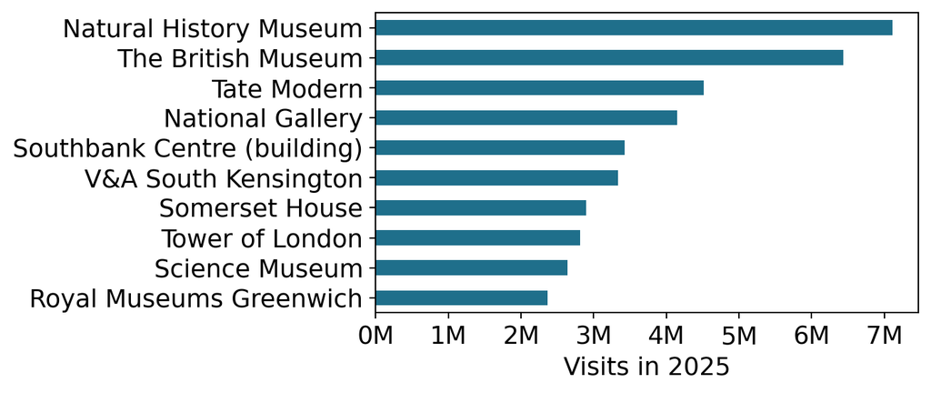

Figure 1: Visits in 2025 (ALVA).

````markdown
```{python}
#| label: fig-top10
#| echo: false
#| fig-cap: "Visits in 2025 (ALVA)."
#| fig-alt: "Bar chart of visits by attraction."
top10 = attractions.sort_values("visits_2025")
top10.plot.barh(x="attraction", y="visits_2025", legend=False)
```
````

### Exercise · ⏱️ 2 min

😰 Stuck?

```
Catch me up: follow ../quarto-workshop/checkpoints/02-london-qmd/README.md
```

the figure has a number, a caption and no code.

## 🖨️ One source, three formats

```yaml
format:
  html:
    format-links:
      - docx
      - {format: typst, text: PDF}
  docx: default
  typst: default
```

`uv run quarto render london.qmd` → `london.html` · `london.docx` · `london.pdf`

🎯 one format only: `--to docx`

### Exercise · ⏱️ 2 min

😰 Stuck?

```
Catch me up: follow ../quarto-workshop/checkpoints/02-london-qmd/README.md
```

`london.docx` and `london.pdf` show the sentence and the chart.

## 🎞️ Three more formats · ⭐ optional

```yaml
format:
  html:
    format-links:
      # … docx, PDF
      - pptx
      - epub
      - {format: revealjs, text: Slides}
  pptx: default
  epub: default
  revealjs: {output-file: london-slides.html}
```

`uv run quarto render london.qmd` → six files

👀 watch the demo · try it later: PowerPoint or LibreOffice, an e-book reader, a browser

### Exercise · ⏱️ 2 min

😰 Stuck?

```
Catch me up: follow ../quarto-workshop/checkpoints/02-london-qmd/README.md
```

all six files show the sentence and the chart.

# 🗂️ One guide, five audiences

⏱️ 0:45

## 🧠 Content once, format per audience

👔

**Managers**

📈 dashboard

`format: dashboard`

📧

**Partners**

email attachment

`format: docx`

🧾

**Walk-ins**

A5 flyer · pdf

`typst` · `papersize: a5`

📱

**Social**

12 cm square ad · pdf

raw `{=typst}` page size

🌐

**Visitors**

website · next block

`project: website`

🔁 change `data/` once → every version updates

## 🤖 Sub-agents: one lead, many hands

🧑‍✈️

**Lead**

your assistant: splits the work, waits, renders, checks

🤖🤖🤖🤖

**Sub-agents**

one task each, own context, all at once

📄

**One file each**

no two agents edit or render the same file

⏱️ four tasks ≈ the slowest one · 🪙 more tokens

[Claude Code](https://code.claude.com/docs/en/sub-agents) · [Codex](https://learn.chatgpt.com/docs/agent-configuration/subagents) · [Antigravity](https://antigravity.google/docs/subagents?tab=cli) · checked 2026-10-31

## 🗂️ One prompt, four audiences

### Exercise · ⏱️ 6 min

😰 Stuck?

```
Catch me up: follow ../quarto-workshop/checkpoints/04-london-audiences/README.md
```

you open a two-page dashboard, a Word brief and its email, a one-page flyer and a square ad.

## 🪟 WSL ↔︎ Windows · ⭐ optional

🐧 Ubuntu

- ➕ Ctrl+Shift+D, then `cd ~/london-guide`
- 📂 `explorer.exe .` in File Explorer
- 💽 `ls /mnt/c/Users/` Windows files
- 🧑‍💻 `code .` VS Code, if installed

🪟 PowerShell

- ➕ ▾ menu → PowerShell
- 📋 `wsl -l -v` Ubuntu · Running · 2
- 🔑 `wsl --user root` reset a password
- ⚠️ `wsl --shutdown` stops every Ubuntu tab

🪟 Windows only · 🍎 `open .` · 👀 approve in the assistant’s tab

### Exercise · ⭐ self-paced

File Explorer shows your `london-guide` files and `wsl -l -v` lists Ubuntu.

## ⌨️ Terminal keys · ⭐ optional

📋 **Ctrl+Shift+C / V**

copy · paste (🍎 ⌘C / ⌘V)

🖱️ **Right-click**

🪟 copy a selection, or paste

✋ **Ctrl+C**

stop a command (🪟 copies a selection)

⇥ **Tab**

complete a name

↔︎️ **Ctrl+A / Ctrl+E**

line start · end

✂️ **Ctrl+U / Ctrl+K**

delete before · after the cursor (🍎 U: whole line)

🧹 **Ctrl+L**

clear the screen

🔎 **Ctrl+R**

search past commands

Ctrl+Shift+D (🍎 ⌘T) → `ls ~/quarto-w` Tab Enter → Ctrl+L → Ctrl+R `ls` → Ctrl+A → Ctrl+E → Ctrl+U

### Exercise · ⭐ self-paced

Ctrl+R found your `ls` command and Ctrl+U cleared it.

# 🌍 Publish to GitHub Pages

⏱️ 0:55

## 🌳 Git: every change, safely

🕰️ every saved version kept · 🐙 shared on GitHub

🌿

**branch**

`main` stays untouched

💾

**commit**

a snapshot + why

☁️

**push**

copy it to GitHub

🔀

**pull request**

propose the change

👀

**review**

someone reads the diff

✅

**merge**

into `main`

👤 today: straight to `main` · 👥 a team: the whole loop

## 🌐 GitHub Pages

[figure not shown]

🆓 free static hosting, straight from a GitHub repo

## 🏗️ A project: one folder → one website

```yaml
project:
  type: website
website:
  title: "Visit London"
  navbar:
    left:
      - {text: Guide, href: london.qmd}
      - {text: Dashboard, href: london-dashboard.qmd}
      - {text: Downloads, menu: [...]}
```

writes 3 files · `uv run quarto render` → `_site/`

`uv run quarto preview`

### Exercise · ⏱️ 3 min

😰 Stuck?

```
Catch me up: follow ../quarto-workshop/examples/london/README.md
```

the site opens with Guide, Dashboard and Downloads.

## 🚀 Publish

approve the `gh` and `quarto publish` commands · open the URL on your phone 📱 · 404? wait a minute, reload

### Exercise · ⏱️ 5 min

😰 Stuck?

```
Catch me up: follow ../quarto-workshop/examples/london/README.md
```

`https://<your-github-username>.github.io/london-guide/london-dashboard.html` opens on your phone 📱

## 📚 Part 1 sources

- 📊 ALVA, *Visits made in 2025 to visitor attractions in membership with ALVA*: alva.org.uk/details.cfm?p=423, retrieved 2026-10-30
- 📈 ALVA, same tables for 2015–2024: `p=` 606 · 607 · 608 · 609 · 610 · 615 · 616 · 617 · 618 · 619, retrieved 2026-10-30
- 📷 *Big Ben in the sun*, John Dillenbeck, CC0: [Wikimedia Commons](https://commons.wikimedia.org/wiki/File:Big_Ben_in_the_sun.jpg), checked 2026-10-30
- 🚇 Stations and admission: [British Museum](https://www.britishmuseum.org/visit) · Natural History Museum ([getting here](https://www.nhm.ac.uk/visit/getting-here.html), [tickets](https://www.nhm.ac.uk/visit.html)) · [Tate Modern](https://www.tate.org.uk/visit/tate-modern) · [National Gallery](https://www.nationalgallery.org.uk/visiting/access) · [TfL Charing Cross](https://tfl.gov.uk/tube/stop/940GZZLUCHX/charing-cross-underground-station) · [Tower of London](https://www.hrp.org.uk/tower-of-london/visit/getting-here/) · [TfL Journey Planner](https://tfl.gov.uk/plan-a-journey/), checked 2026-10-30
- 📘 Docs: [Typst](https://quarto.org/docs/output-formats/typst.html) · [inline code](https://quarto.org/docs/computations/inline-code.html) · [dashboards](https://quarto.org/docs/dashboards/data-display.html) · [GitHub Pages](https://quarto.org/docs/publishing/github-pages.html) · [gh repo create](https://cli.github.com/manual/gh_repo_create), checked 2026-10-30

# ☕ Break

⏱️ 1:05

☕ 10 min · back at **1:15** for 💧 Part 2

🛟 London site not live yet? Ask for help now, or paste the 🚀 Publish slide’s **Catch me up**

# 💧 Part 2 · Colombia water quality and infant mortality

⏱️ 1:15

## 🗺️ Part 2 in seven stages

💧

**1:15** why · rules · data

🔍

**1:30** explore

🧹

**1:45** prepare

🧩

**2:00** cluster

🏷️

**2:15** interpret

⚠️

**2:30** correlation ≠ causation

📤

**2:40** publish many

🏁 a live site: report · slides · blog · dashboard

## 📏 Two measures: IRCA and Saber 11

💧 IRCA · water-quality risk

- 🧪 tap-water samples against health limits
- ⚖️ failed tests weighted by risk: *E. coli* 25 · turbidity 15 · pH 1.5
- 📏 0 = no risk → 100 = unfit

🎓 Saber 11 · ICFES exam

- 🧑‍🎓 students finishing secondary school
- 📚 5 tests: reading, maths, social studies, science, English
- 📏 global score 0–500

🧮 both are averages: IRCA over water samples · Saber 11 over students

Resolución 2115 de 2007, arts. 13–14 ([normas.cra.gov.co](https://normas.cra.gov.co/gestor/docs/resolucion_minproteccion_2115_2007.htm)) · ICFES, *Saber 11.° Guía de orientación 2017-1*, pp. 101 and 104 ([icfes.gov.co](https://www.icfes.gov.co/wp-content/uploads/2024/11/Guia-de-orientacion-saber-11-2017-1.pdf))

## 🚰 Why drinking water?

**0–5**

✅ sin riesgo · no risk

**5.1–14**

🟡 bajo · low

5.7

🏙️ urban

7.4

🏭 utilities

**14.1–35**

🟠 medio · medium

16.4

🇨🇴 national

**35.1–80**

🔴 alto · high

36.5

🌾 rural

43.7

🪣 self-supplied

**80.1–100**

⛔ inviable sanitariamente · unfit

INS IRCA for 2023: MinSalud, MinVivienda, INS and Superservicios, *INCA 2023* (Bogotá, January 2025), Tabla 4 · bands: Resolución 2115 de 2007, art. 15 ([normas.cra.gov.co](https://normas.cra.gov.co/gestor/docs/resolucion_minproteccion_2115_2007.htm))

## 🧠 The question

🧩 Which **kinds** of municipality exist?

🎯 How do 👶 health and 🎓 education outcomes **differ** between them?

## 📦 One analysis, many deliverables

[figure not shown]

## 🗃️ The dataset

```bash
cd ~ && mkdir -p water-quality && cd water-quality
claude
```

1 row = 🏘️ municipality × 🏙️/🌾 zone × 📅 year

📊 31,416 rows · 28 columns · 1,122 codes · 2010–2023 · 📖 `data/README.md`

## 📜 Rules for the analysis

reads `data/README.md` · writes `AGENTS.md`: scope, rules, the data’s caveats

approve · check that every rule is there

### Exercise · ⏱️ 2 min

😰 Stuck?

```
Catch me up: follow ../quarto-workshop/checkpoints/05-water-explore/README.md
```

`AGENTS.md` states the analysis’ scope and its four rules.

## 📦 The project’s environment

📦 `pyproject.toml` · 🔒 `uv.lock` · `.venv/` · a rule in `AGENTS.md`

approve · preview from now on: `uv run quarto preview`

### Exercise · ⏱️ 2 min

😰 Stuck?

```
Catch me up: follow ../quarto-workshop/checkpoints/05-water-explore/README.md
```

`uv run quarto check jupyter` shows this project’s `.venv` Python.

## 🧩 Features vs 🎯 outcomes

**🧩 Cluster on**

Water

- 💧 IRCA (prestadores)
- 🚰 piped water
- 🚽 sewer

People & place

- 💸 poverty (IPM)
- 🌾 rural share
- ⛰️ altitude (derived)
- 🌧️ rainfall

Government

- 🏛️ municipal performance (MDM)
- 💰 water transfers per person (SGP)

**🎯 Only compare**

👶 infant mortality

🎓 Saber 11 score

🎒 school dropout

🚫 never cluster on outcomes

## 🔁 Compute once, publish many

```
data/water_municipal.csv
        │   uv run python scripts/analysis.py
        ▼
outputs/clusters.parquet  +  outputs/cluster_profiles.csv
        │   every page reads them
        ▼
explore · clusters · report · slides · blog · dashboard
```

🧮 compute once → 📤 never copy a number by hand

# 🔍 Explore

⏱️ 1:30

## 🔍 Look before you model

📐

rows × columns

❔

missing by column × zone

🎚️

IRCA by band × zone

📈

IRCA by year

## 🌾 Rural: less data, more risk

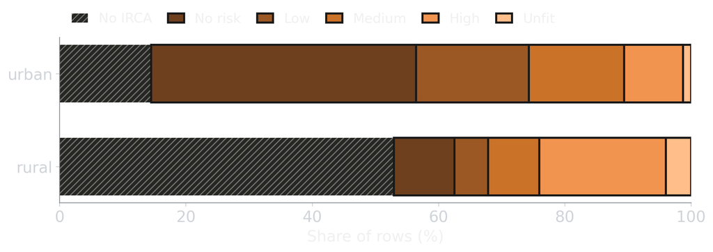

Figure 2: All rows, 2010–2023, by zone: no IRCA reported (hatched grey) and Resolución 2115 risk band. Utility-supplied (prestadores) IRCA, INS open data nxt2-39c3.

❔ rural rows without IRCA: **53%** · 🔴 rural rows with IRCA in high or unfit: **51%**

## 🔍 Explore the data

writes `explore.qmd` · `uv run quarto render explore.qmd`

open `explore.html` in your browser

### Exercise · ⏱️ 10 min

😰 Stuck?

```
Catch me up: follow ../quarto-workshop/checkpoints/05-water-explore/README.md
```

`explore.html` shows IRCA by zone for 2010–2023.

# 🧹 Prepare

⏱️ 1:45

## 🧹 Four steps from table to features

✂️

**select** 2016–2023 · municipalities · with IRCA

🔄

**transform** log SGP · capitals use the municipal total 🚩

🩹

**impute** year × zone median 🚩

📏

**standardise** z-score within year

🚩 = a flag column, so nothing is filled silently

## 🧮 What we keep

| step | rows |
| --- | --- |
| 🏘️ municipality rows, 2016–2023 | 17,648 |
| ❌ no IRCA | 6,411 |
| ❌ more than 2 features missing | 2 |
| ✅ **kept**: 7,534 urban + 3,701 rural | **11,235** |

🏘️ 1,090 municipalities · 🩹 653 rows imputed · 🏛️ 214 capital rows from totals

## 📏 Why scale?

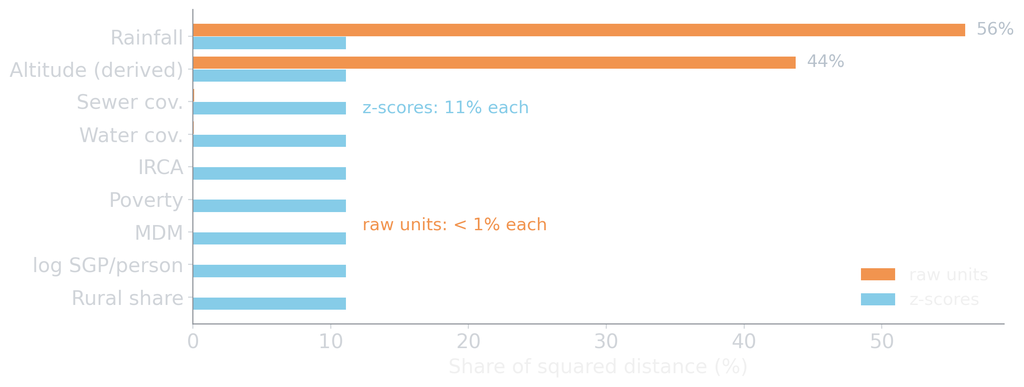

Figure 3: Share of the squared distance between rows that each feature contributes, in raw units and after z-scores (kept rows, 2016–2023).

⛰️🌧️ raw units: altitude + rainfall = **99.8%** of the distance

## 🧹 Select and transform

writes `scripts/analysis.py` · runs `uv run python scripts/analysis.py`

### Exercise · ⏱️ 5 min

😰 Stuck?

```
Catch me up: follow ../quarto-workshop/checkpoints/06-water-prepare/README.md
```

`prepare()` returns one row per kept zone-year with the nine features.

## 🧹 Impute and scale

edits `prepare()` · `uv run python scripts/analysis.py`

### Exercise · ⏱️ 5 min

😰 Stuck?

```
Catch me up: follow ../quarto-workshop/checkpoints/06-water-prepare/README.md
```

the printed counts match 🧮 *What we keep*: 11,235 rows kept.

# 🧩 Cluster

⏱️ 2:00

## 🧩 k-means in four steps

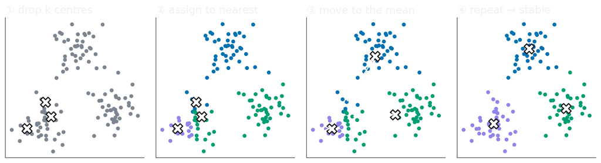

Figure 4: Synthetic toy points, not the water data: k-means with k = 3.

✕ = centre · 🎯 goal: points close to their centre

💧 water data: **k = 4** is a hyperparameter, picked from k = 2–8 by elbow + silhouette

## 🫧 A picture of the clusters

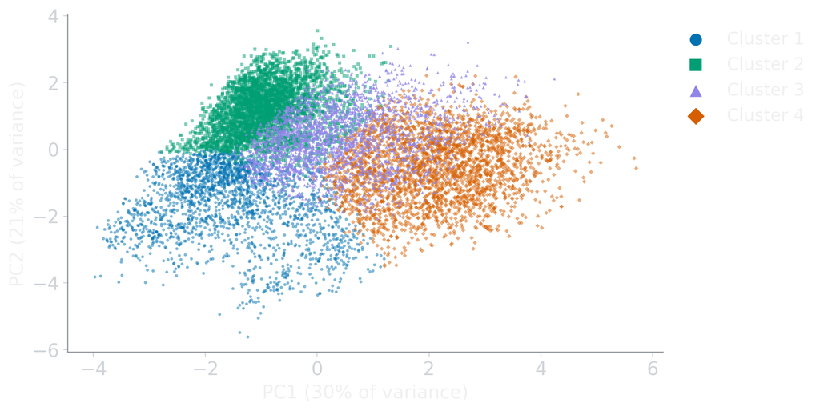

Figure 5: Each dot is a zone-year on the first two principal components of the 9 z-scored features, coloured by cluster. PCA is only for the picture; k-means used all 9 features.

## 🌀 Turn the cloud

● Cluster 1■ Cluster 2▲ Cluster 3◆ Cluster 4

PC1 · 30%PC2 · 21%PC3 · 16%

🫧 2 axes · 51% of variance · cluster 3: 53% of near neighbours in it

🔄 3 axes · 67% · 90%

PC3 ≈ ⛰️ altitude (derived) − 🌧️ rainfall: cluster 3 sits below the others

Each point is a zone-year on the first three principal components of the 9 z-scored features, by cluster · 🖱️ drag to turn · scroll to zoom

## 🏔️ Where the clusters stand

■ Cluster 1 · 1,256 m■ Cluster 2 · 1,766 m■ Cluster 3 · 130 m■ Cluster 4 · 159 m

BogotáTunjaMedellínCaliBarranquillaCartagenaCúcutaBucaramangaVillavicencioValleduparIbagué

🗺️ 966 urban zones, 2023: a column each, coloured by cluster

⛰️ height = head-town altitude, ×50

🏔️ cluster 2: median 1,766 m · cluster 3: 130 m

Columns stand at municipality centroids; heights are derived SRTM altitudes of the head towns · labels: the 10 most populous department capitals and Tunja · 🖱️ drag to turn · scroll to zoom

## 🛤️ Use the model, or build it

📤

**Use it** · the normal route

copy each block’s finished `analysis.py`, then build the pages

🧗

**Build it** · ⭐ challenge

paste the ⭐ prompts · stuck? the 📤 prompt

### Exercise · ⏱️ 2 min

😰 Stuck?

```
Catch me up: follow ../quarto-workshop/checkpoints/07-water-cluster/README.md
```

`outputs/clusters.parquet` exists and you know k.

## 🧩 Run k-means · ⭐ challenge

edits `scripts/analysis.py` · `uv run python scripts/analysis.py`

### Exercise · ⏱️ 6 min

😰 Stuck?

```
Catch me up: follow ../quarto-workshop/checkpoints/07-water-cluster/README.md
```

`outputs/clusters.parquet` has a cluster for every kept row, and 🤔 you can explain its choice of k.

## 🧩 The clusters page

writes `clusters.qmd` · `uv run quarto render clusters.qmd`

open `clusters.html` in your browser

### Exercise · ⏱️ 6 min

😰 Stuck?

```
Catch me up: follow ../quarto-workshop/checkpoints/07-water-cluster/README.md
```

`clusters.html` shows the elbow, the silhouette and the PCA picture.

# 🏷️ Interpret

⏱️ 2:15

## 🌡️ What sets each cluster apart?

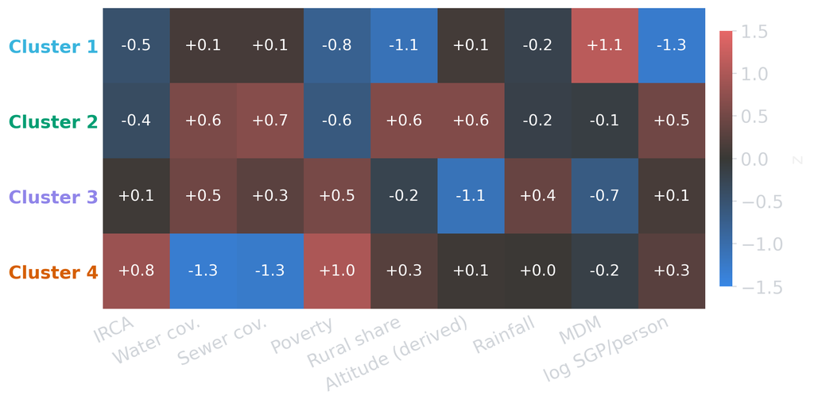

Figure 6: Cluster centroids in z units: standard deviations above (red) or below (blue) the year’s average. IRCA: utility-supplied (prestadores). Altitude: derived SRTM point.

## 🏷️ Name them by a rule

🏷️ name = 🏙️ setting + 🚰 coverage + 🎚️ median IRCA band

|  | Kind | Zone-years | Municipalities | Median IRCA |
| --- | --- | --- | --- | --- |
| 1 | Cities and large towns, no-risk water | 2,271 | 284 | 1.6 |
| 2 | Highland towns, no-risk water | 3,750 | 558 | 4.0 |
| 3 | Lowland towns, low-risk water | 2,451 | 479 | 9.2 |
| 4 | Rural, low-coverage, high-risk water | 2,763 | 729 | 35.2 |

“low-coverage” = 0.5 SD or more below the year’s average, not “unserved” · risk word = band of the cluster’s **median** utility-supplied (prestadores) IRCA, not every zone-year’s

## 🎯 Outcomes by cluster

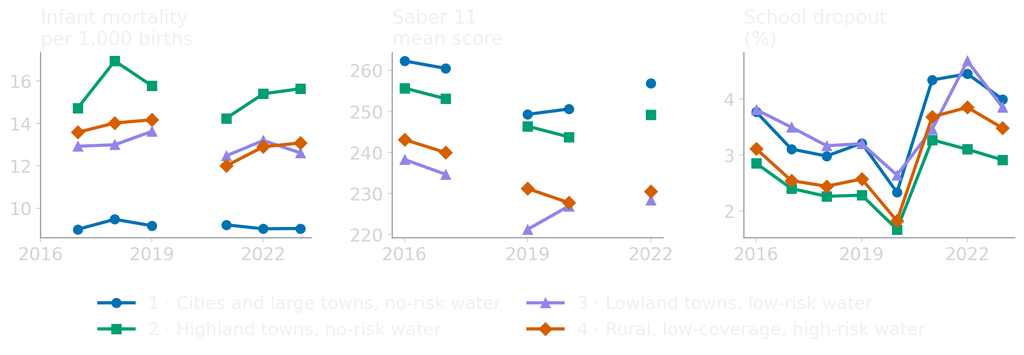

Figure 7: Median by cluster and year. Infant mortality: 2017–2019 and 2021–2023 only (its method changes in 2017; 2020 looks like another source). Saber 11: published years.

⚠️ Descriptive only: these differences are not causal effects of water quality. Infant mortality and dropout are municipal values.

## 🌡️ Outcomes in SD units

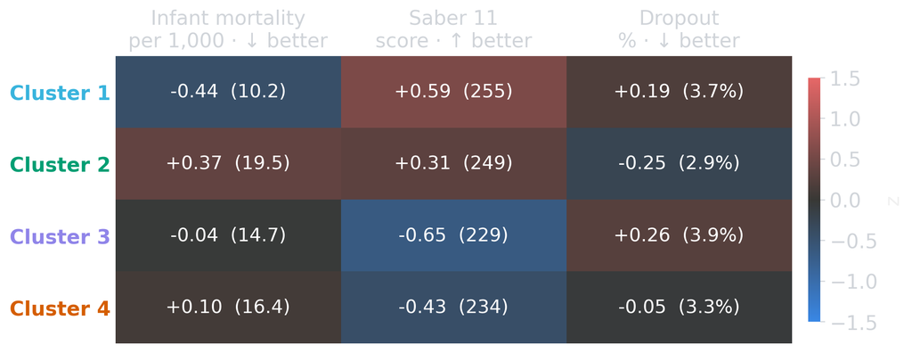

Figure 8: Cluster mean outcome in z units (SD above red, below blue the year’s average); the mean itself in brackets. Colour scale as in the features heatmap.

⚠️ Descriptive only: not causal effects of water quality. Infant mortality: 2017–2019 and 2021–2023; Saber 11: published years.

## 🎛️ Every variable, cluster by cluster

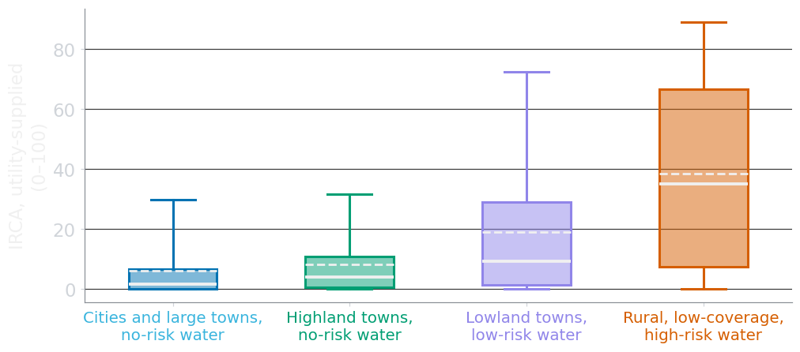

▭ middle half · ━ median · ┅ mean · whiskers 5th–95th percentile · all zone-years 2016–2023; outcomes in their years, municipal ones once per municipality

## 📤 Use the outcome rules and names

copies · runs · writes `outputs/outcomes_by_year.csv` and `outputs/cluster_profiles.csv`

🧗 building it yourself? the next two ⭐ slides instead

### Exercise · ⏱️ 2 min

😰 Stuck?

```
Catch me up: follow ../quarto-workshop/checkpoints/08-water-interpret/README.md
```

the assistant shows a name for every cluster.

## 🏷️ Outcome rules · ⭐ challenge

adds the outcome rules and `outcomes_by_year()` · `uv run python scripts/analysis.py`

### Exercise · ⏱️ 3 min

😰 Stuck?

```
Catch me up: follow ../quarto-workshop/checkpoints/08-water-interpret/README.md
```

`outputs/outcomes_by_year.csv` has no infant-mortality rows for 2016 or 2020.

## 🏷️ Profiles and names · ⭐ challenge

adds `profiles()` and a naming rule · `uv run python scripts/analysis.py`

### Exercise · ⏱️ 3 min

😰 Stuck?

```
Catch me up: follow ../quarto-workshop/checkpoints/08-water-interpret/README.md
```

every cluster has a name you can defend from its profile.

## 🏷️ Heatmap and outcomes

edits `clusters.qmd` · `uv run quarto render clusters.qmd`

reload `clusters.html` in your browser

💬 while it renders, with a neighbour: describe one cluster using two features.

### Exercise · ⏱️ 4 min

😰 Stuck?

```
Catch me up: follow ../quarto-workshop/checkpoints/08-water-interpret/README.md
```

`clusters.html` shows the heatmap and outcomes by cluster and year.

# ⚠️ Correlation ≠ causation

⏱️ 2:30

## 📉 Worse water, more infant deaths?

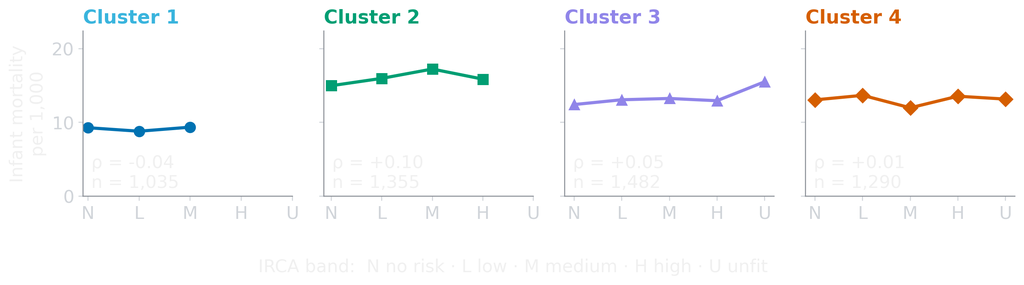

Figure 9: Median infant mortality by utility-supplied (prestadores) IRCA band, per cluster. Infant mortality changes method in 2017, and 2020 looks like another source: 2017–2019 and 2021–2023 are pooled. Bands under 20 municipality-years are not drawn.

⚠️ descriptive only: **not** a causal effect of water quality

## 🤔 What else could explain it?

💸

**poverty**

🌾

**rurality**

🏥

**health-service access**

📝

**reporting quality**

🔍

**ecological level**: municipal outcome, zone IRCA

## 📤 Use the within-cluster check

copies · runs · writes `outputs/irca_infant.csv` and `outputs/irca_infant_bins.csv`

🧗 building it yourself? the next ⭐ slide instead

### Exercise · ⏱️ 2 min

😰 Stuck?

```
Catch me up: follow ../quarto-workshop/checkpoints/09-water-causation/README.md
```

ρ and n are printed for every cluster.

## 🧮 Within-cluster check · ⭐ challenge

adds `irca_vs_infant()` · `uv run python scripts/analysis.py`

### Exercise · ⏱️ 3 min

😰 Stuck?

```
Catch me up: follow ../quarto-workshop/checkpoints/09-water-causation/README.md
```

ρ and n are saved and printed for every cluster.

## ⚠️ Show it + discuss

edits `clusters.qmd` · `uv run quarto render clusters.qmd`

💬 while it runs, with a neighbour: pick one confounder: could it hide a real effect, or create a fake one?

### Exercise · ⏱️ 3 min

😰 Stuck?

```
Catch me up: follow ../quarto-workshop/checkpoints/09-water-causation/README.md
```

`clusters.html` shows ρ and n per cluster, and you can say how one confounder could bias it.

# 📤 Publish many

⏱️ 2:40

## 📄 2:40 · Report → docx + PDF

writes `report.qmd` · `uv run quarto render report.qmd`

open `report.docx` (Word or LibreOffice) and `report.pdf`

### Exercise · ⏱️ 8 min

😰 Stuck?

```
Catch me up: follow ../quarto-workshop/checkpoints/10-water-report/README.md
```

`report.docx` and `report.pdf` open with the heatmap and the outcomes figure.

## 📊 2:50 · Slides → revealjs + pptx

writes `slides.qmd` · `uv run quarto render slides.qmd`

open `slides.html` in your browser and `slides.pptx` in PowerPoint or LibreOffice

### Exercise · ⏱️ 4 min

😰 Stuck?

```
Catch me up: follow ../quarto-workshop/checkpoints/11-water-slides/README.md
```

`slides.html` and `slides.pptx` both have 6 slides.

## 📖 Report → ePub · ⭐ optional

```yaml
lang: en        # the e-book's language
format:
  html:
    format-links:
      # … Word, PDF
      - text: ePub
        format: epub
  epub:
    toc: true
```

edits `report.qmd` · `uv run quarto render report.qmd`

open `report.epub` in an e-book reader (Calibre, or Books on a Mac)

### Exercise · ⏱️ 4 min

😰 Stuck?

```
Catch me up: follow ../quarto-workshop/checkpoints/12-water-epub/README.md
```

`report.epub` opens with the three figures and the sources.

## ✍️🌐 2:55 · Blog + website

```yaml
# _quarto.yml
project:
  type: website
  execute-dir: project
  pre-render: scripts/analysis.py
execute:
  freeze: false
```

```yaml
# index.qmd
listing:
  contents: posts
```

🔁 `pre-render` rebuilds `outputs/`

🧪 `freeze: false` re-runs **every** page → always the new numbers

⭐ later, for slow sites: `freeze: auto` reuses old results  
until you run `rm -rf _freeze`

## ✍️🌐 Website + post

writes 3 files · `uv run quarto render` → `_site/`

`uv run quarto preview`

### Exercise · ⏱️ 8 min

😰 Stuck?

```
Catch me up: follow ../quarto-workshop/checkpoints/13-water-website/README.md
```

the site lists one post whose title states the real k.

## 📈 3:05 · Dashboard

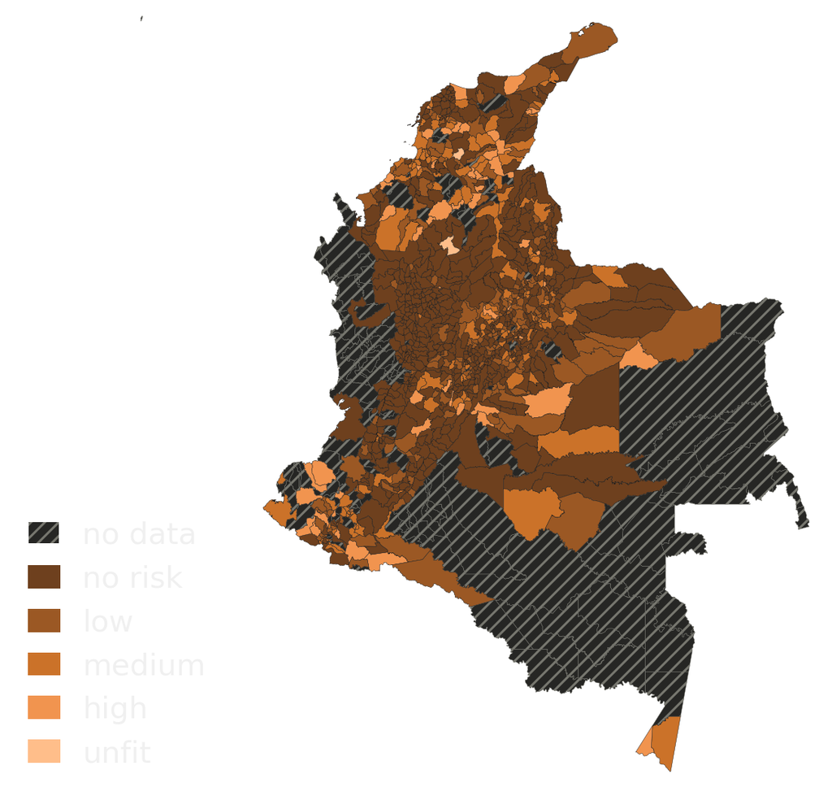

Figure 10: Urban zones, 2023: utility-supplied (prestadores) IRCA band.

🗺️ choropleth: `municipios.geojson` joined on `divipola`

🎚️ year slider: 2016 → 2023

🔎 search a department → its municipalities

🗂️ two pages: map · table

## 📈 Build the dashboard

writes `dashboard.qmd` · edits `_quarto.yml` · `uv run quarto render`

reload the preview (or `uv run quarto preview`) → 📈 Dashboard

### Exercise · ⏱️ 8 min

😰 Stuck?

```
Catch me up: follow ../quarto-workshop/examples/water/README.md
```

the map changes when you move the year slider.

## 📈 Three more dashboard pages · ⭐ optional

🧬 Kinds · 🎯 Outcomes · 📐 Method (why k = 4), from `outputs/`

reload 📈 Dashboard · open each page

### Exercise · ⏱️ 8 min

😰 Stuck?

```
Catch me up: follow ../quarto-workshop/examples/water/README.md
```

the dashboard has Map, Kinds, Outcomes, Method and Municipalities pages.

## 🌍 3:15 · Publish it

approve the `gh` and `quarto publish` commands · open the live URL

💬 while it publishes: which file would you change to update every publication?

### Exercise · ⏱️ 4 min

😰 Stuck?

```
Catch me up: follow ../quarto-workshop/examples/water/README.md
```

`https://<your-github-username>.github.io/water-quality/` opens in a browser.

## 🚀 Extra challenges

🔀

**Sankey**: cluster moves between years

⭐

**positive deviants**: good outcomes despite risky water

🧪

**GMM · HDBSCAN**: soft or density clusters

🦠

**SIVIGILA**: diarrhoeal disease incidence, once available

## 📚 Sources

- 💧 IRCA: INS, *Calidad del Agua para Consumo Humano en Colombia*, datos.gov.co [`nxt2-39c3`](https://www.datos.gov.co/resource/nxt2-39c3.csv), CC BY-SA 4.0 (utility-supplied, prestadores)
- 🎚️ Bands: MinProtección Social and MAVDT, [Resolución 2115 de 2007, art. 15](https://normas.cra.gov.co/gestor/docs/resolucion_minproteccion_2115_2007.htm) · 🇨🇴 MinSalud, MinVivienda, INS and Superservicios, [*INCA 2023*](https://www.minvivienda.gov.co/sites/default/files/documentos/informe-nacional-de-calidad-del-agua-para-consumo-humano-inca-2023.pdf) (Bogotá, January 2025), Tabla 4
- 🏛️ Coverage, poverty, MDM, SGP, region, infant mortality: DNP [TerriData](https://terridata.dnp.gov.co/) (Superservicios, DANE, DNP-SICODIS, MinSalud)
- 🗺️ DANE: DIVIPOLA [`gdxc-w37w`](https://www.datos.gov.co/resource/gdxc-w37w.json) · population projections [2005–2017](https://www.dane.gov.co/files/censo2018/proyecciones-de-poblacion/Municipal/DCD-area-proypoblacion-Mun-2005-2017_VP.xlsx), [2018–2042](https://www.dane.gov.co/files/censo2018/proyecciones-de-poblacion/Municipal/PPED-AreaMun-2018-2042_VP.xlsx) · [MGN 2023](https://geoportal.dane.gov.co/descargas/mgn_2023/MGN2023_MPIO_POLITICO.zip)
- 🎓 Saber 11: ICFES [`kgxf-xxbe`](https://www.datos.gov.co/resource/kgxf-xxbe.csv), [`rnvb-vnyh`](https://www.datos.gov.co/resource/rnvb-vnyh.csv) · 🎒 dropout: MEN [`nudc-7mev`](https://www.datos.gov.co/resource/nudc-7mev.csv)
- 🌧️ Rainfall: [CHIRPS v3.0](https://www.chc.ucsb.edu/data/chirps3), Funk et al. (2026), *Scientific Data* 13, 718, [doi:10.1038/s41597-026-07096-4](https://doi.org/10.1038/s41597-026-07096-4); data [doi:10.15780/G2JQ0P](https://doi.org/10.15780/G2JQ0P); Funk et al. (2015), *Scientific Data* 2, 150066, [doi:10.1038/sdata.2015.66](https://doi.org/10.1038/sdata.2015.66)
- ⛰️ Altitude (derived): NASA SRTM GL3, [doi:10.5067/MEaSUREs/SRTM/SRTMGL3.003](https://doi.org/10.5067/MEaSUREs/SRTM/SRTMGL3.003), via [OpenTopoData](https://www.opentopodata.org/datasets/srtm/)
- 📘 Docs: [scripts](https://quarto.org/docs/projects/scripts.html) · freeze · [listings](https://quarto.org/docs/websites/website-listings.html) · [dashboards](https://quarto.org/docs/dashboards/) · [Typst](https://quarto.org/docs/output-formats/typst.html) · [ePub](https://quarto.org/docs/reference/formats/epub.html), checked 2026-10-30

# 🏁 Done

⏱️ 3:20

## 🙌 What you built

🇬🇧

London guide: html · docx · pdf · dashboard · email · flyer · ad · live site (⭐ pptx · revealjs · epub)

💧

Water analysis: report (docx · pdf · ⭐ epub) · slides (pptx · revealjs) · blog · dashboard · live site

🔁

One source, many outputs, rebuilt with one command

📚 [Quarto guide](https://quarto.org/docs/guide/) · [Dashboards](https://quarto.org/docs/dashboards/) · [Typst](https://quarto.org/docs/output-formats/typst.html) · [GitHub Pages](https://quarto.org/docs/publishing/github-pages.html)

➡️ Next: AI workflows: promotion experiments and sales outcomes